# Rapport SAE S204

## Composition du groupe (Groupe 4):

```
Essalhi Ayoub
Leroux Mathieu
Rouge Gabriel
```

### Sommaire :

```
I : Introduction
II : Visualisations prévues à l'effet interne
III : Visualisations prévues à l'effet des propriétaires
IV : Visualisations prévues à l'effet des acheteurs
V : Cahier de bord
VI : Conclusion
```

## Introduction

Pour effectuer cette partie de la SAE, nous avons tenté de s'imaginer, à la manière d'un jeu de rôle, comme de vrais agents immobiliers. Ainsi nos interrogations sur comment orienter notre travail se sont faites dans cette idée : quelles statistiques montrer, comment, et dans quelles circonstances ; comment rendre cela pratique pour une véritable agence immobilière ?

Notons que les statistiques utilisées ont été confectionnées par nos soins seulements et dans une période de temps réduite : elles ne représentent évidemment pas la réalité. En addition, même si notre volonté était la diversité et la cohérence, il ne s'agira là que d'un simple simuli qui peut dans certaines exceptions avoir des incohérences.

Pour organiser nos visualisation, nous avons réfléchi à trois situations dans lequelles elles peuvent être d'usage ; à l'usage interne (pour l'entreprise seulement, afin qu'elle prenne des décisions), à l'usage des propriétaires (qui cherchent une agence immobilière où mettre en vente leurs biens), et à l'usage des achetteurs (qui cherche à acheter un bien). Etant donné que certains diagrammes peuvent être utiles à plusieurs instance différentes, nous avons dû trancher en décidant d'après notre intuition où le diagramme serait le plus utile.

A postériori de ces trois parties, nous clôturerons par une brève conclusion.

Pour composer ce devoir, comme la consigne le précisait, voici les trois bibliothèques python que nous avons utilisé :

```python
import matplotlib.pyplot as plt
import pandas as pd
import numpy as np
```

Et voici l'extraction des fichiers CSV qui ont été produits suite à la première partie d'exercices sur la SQL et les bases de données.

```python
bien = pd.read_csv("bien.csv")
espace = pd.read_csv("espace.csv")
proprio = pd.read_csv("proprio.csv")
```

## Visualisations prévues à l'effet interne

Ces visualisations ont leur utilisation prévue pour les réunions, la direction, le service marcketing... Toute instance interne à l'agence immobilière en question. En voici une séléction, avec une explication de l'utilité qu'on en propose, et la raison de ceci.

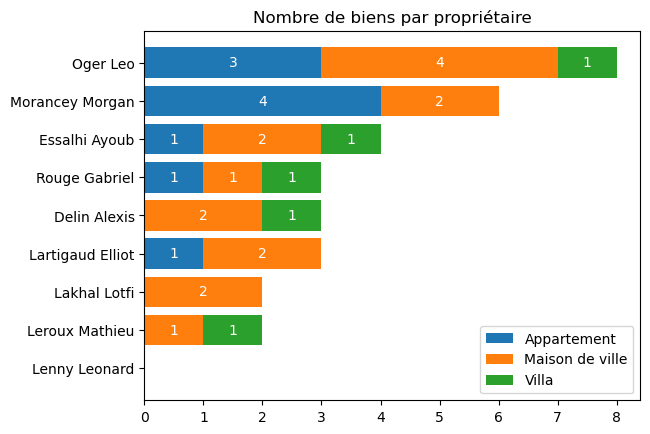

```python
dico = {"Nom": [], "Appartement": [],
        "Maison de ville": [], "Villa": []}
categories = np.unique(bien["CATEGORIE"])
for i in range(len(proprio)):
    dico["Nom"].append(proprio["NOM"][i] + " " + proprio["PRENOM"][i])
    biens_proprio = bien.loc[(bien["IDP"] == proprio["IDP"][i])]
    dico["Appartement"].append(
        len(biens_proprio.loc[biens_proprio["CATEGORIE"] == "Appartement"]))
    dico["Maison de ville"].append(
        len(biens_proprio.loc[biens_proprio["CATEGORIE"] == "Maison de ville"]))
    dico["Villa"].append(
        len(biens_proprio.loc[biens_proprio["CATEGORIE"] == "Villa"]))
dico["Nb_bien"] = np.add(dico["Appartement"], np.add(
    dico["Maison de ville"], dico["Villa"]))
df = pd.DataFrame.from_dict(dico)
df = df.sort_values(by=['Nb_bien'])
fig, ex = plt.subplots()
left = np.zeros(len(df["Nom"]))
for categorie in categories:
    p = ex.barh(df["Nom"], df[categorie], label=categorie, left=left)
    left += df[categorie]
ex.legend(categories)
ax = ex.axes
for patch in ax.patches:
    width = patch.get_width()
    if (width > 0):
        height = patch.get_height()
        x, y = patch.get_xy()
        ex.text(x + width/2, y + height/2, '{:.0f}'.format(width),
                horizontalalignment='center', verticalalignment='center', color='white')
plt.title("Nombre de biens par propriétaire")
plt.show()
```

Ce diagramme en bâton montre la quantité en nombre et la proportion de biens détenus par chacun des propriétaires faisant appel à nos services. Puisque le nombre de propriétaires enregistré n'est pas excessif (il s'agit probablement d'une petite agence), l'on se permet de tous les afficher sur le même diagramme. Ils sont affichés à l'horizontale pour mieux lire les noms des propriétaires et dans l'ordre décroissant pour une meilleure lisibilité.

Cette visualisation permet de faire ressortir les propriétaires qui participent au mieux à l'activité de l'agence (puisqu'ils confient la plus grande quantité de biens). Sur cette information, les instances responsables des décisions et du service-client peuvent entreprendre des stratégies ; offrir des cadeaux aux meilleurs propriétaires, savoir quels propriétaires sont susceptibles ou non d'apporter plus de biens...

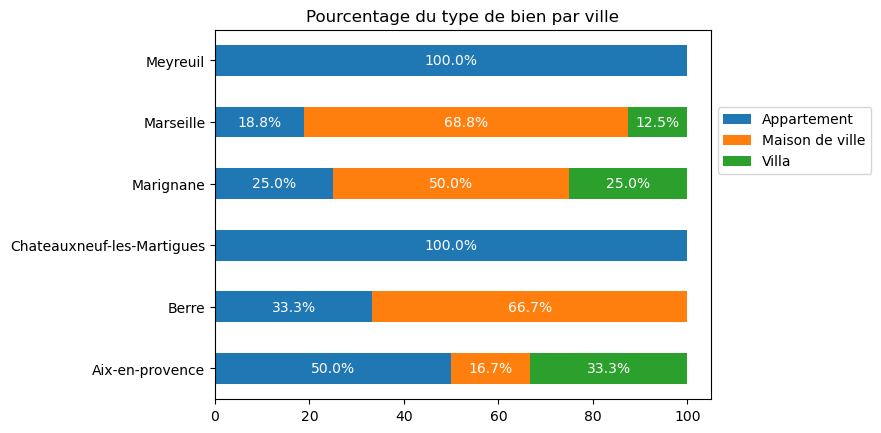

```python
villes = np.unique(bien["VILLE"])
categories = np.unique(bien["CATEGORIE"])
for categorie in categories:
    categorie += "(" + " " + ")"
data = []
for ville in villes:
    data.append([])
    for cat in categories:
        nb_bien_dans_cat = len(
            bien.loc[(bien["VILLE"] == ville) & (bien["CATEGORIE"] == cat)])
        nb_bien_totaux = len(bien.loc[bien["VILLE"] == ville])
        data[-1].append(nb_bien_dans_cat / nb_bien_totaux * 100)
df = pd.DataFrame(
    data, index=villes, columns=categories
)
ex = df.plot.barh(stacked=True, title="Pourcentage du type de bien par ville").legend(
    loc='center left', bbox_to_anchor=(1, 0.7))
ax = ex.axes

for patch in ax.patches:
    width = patch.get_width()
    if (width > 0):
        height = patch.get_height()
        x, y = patch.get_xy()
        ax.text(x + width/2, y + height/2, '{:.1f}%'.format(width),
                horizontalalignment='center', verticalalignment='center', color='white')
```

Ce diagramme en bâton montre la répartition des types de biens par ville, en pourcentage. Il est à l'horizontale pour mieux lire les noms des villes notamment, ainsi que les pourcentages affichés ; et une jauge ainsi faite rend un visuel plus agréable à l'horitontale qu'à la verticale.

Cette information permet de faire état des biens de l'agence, afin de visualiser comment apporter plus de diversité. L'idéal pour une agence serait de proposer de tout types de biens dans plusieurs villes ; on remarque que l'équilibre est atteint dans certaines villes, mais pas dans d'autres. Ainsi, le service marcketing peut considérer de mettre plus d'effort dans la publicité dans certaines villes pour obtenir la main sur différents biens pour compléter le catalogue de l'agence.

## Visualisations prévues à l'effet des propriétaires

Ces visualisations ont leur utilisation prévue pour les propriétaires qui ont un bien déjà entre les mains de l'agence ou qui cherchent une agence pour vendre leur bien. Encore une fois, voici une séléction de visualisation que l'on propose, avec une explication de l'utilité qu'on en propose, et la raison de ceci.

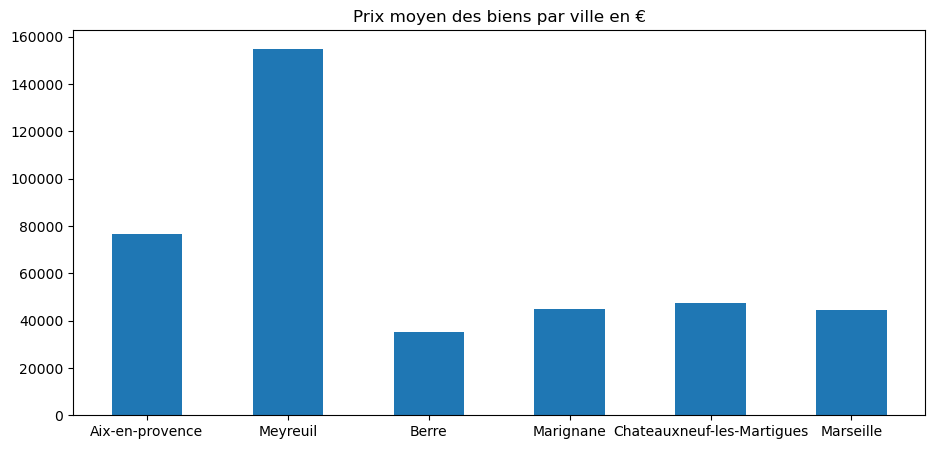

```python
bienappart = bien.loc[bien["CATEGORIE"] == "Appartement"]
dicvilleprix = {}
for i in range (len(bienappart)):
   if (bienappart.iloc[i,:]["VILLE"] not in dicvilleprix):
        dicvilleprix[bienappart.iloc[i,:]["VILLE"]] = [bienappart.iloc[i,:]["PRIX"]]
   else:
        dicvilleprix[bienappart.iloc[i,:]["VILLE"]].append(bienappart.iloc[i,:]["PRIX"])
listville = list(dicvilleprix.keys())
prixmoyen = []
for i in (dicvilleprix):
    prixmoyen.append(np.mean(dicvilleprix[i]))

plt.figure(figsize=(11,5))
plt.title("Prix moyen des biens par ville en €")
plt.bar(listville,prixmoyen,align='center',width=0.5)
plt.show()
```

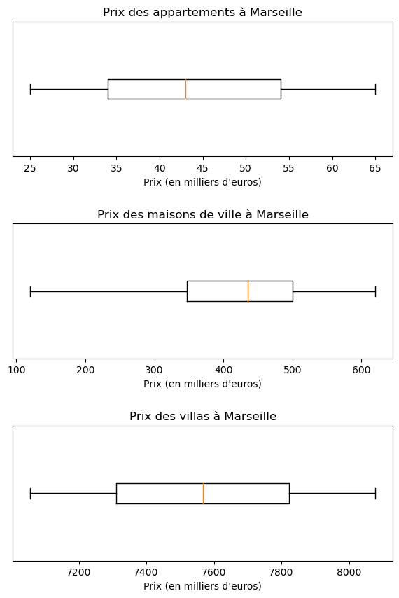

```python
MRSprix_appart = bien.loc[(bien["CATEGORIE"] == "Appartement") & (bien["VILLE"]=="Marseille")]["PRIX"]
MRSprix_maisonville = bien.loc[(bien["CATEGORIE"] == "Maison de ville") & (bien["VILLE"]=="Marseille")]["PRIX"]
MRSprix_villa = bien.loc[(bien["CATEGORIE"] == "Villa") & (bien["VILLE"]=="Marseille")]["PRIX"]

fig, (ax1, ax2, ax3) = plt.subplots(3,1, figsize=(7,10))

ax1.set_title("Prix des appartements à Marseille")
ax1.boxplot(np.multiply(MRSprix_appart,0.001), whis=[0,100], vert=False)
ax1.set_xlabel("Prix (en milliers d'euros)")
ax1.set_yticklabels("")
ax1.tick_params(axis='y', left=False)

ax2.set_title("Prix des maisons de ville à Marseille")
ax2.boxplot(np.multiply(MRSprix_maisonville,0.001), whis=[0,100], vert=False)
ax2.set_xlabel("Prix (en milliers d'euros)")
ax2.set_yticklabels("")
ax2.tick_params(axis='y', left=False)


ax3.set_title("Prix des villas à Marseille")
ax3.boxplot(np.multiply(MRSprix_villa,0.001), whis=[0,100], vert=False)
ax3.set_xlabel("Prix (en milliers d'euros)")
ax3.set_yticklabels("")
ax3.tick_params(axis='y', left=False)

plt.subplots_adjust(hspace=0.5)
plt.show()
```

Ces diagrammes en boîte montre les indicateurs statistique pertinents du prix de chaque catégorie de biens à Marseille. Dû à la trop grande différence de valeurs ils ne peuvent pas figurer sur le même diagramme, mais cela n'obstrue pas à une compréhension éclairée de l'information donnée.

Cette information complémente le dernier diagramme ; en s'accordant à ces indicateurs, les propriétaires peuvent estimer le temps que prendra leur bien à se vendre selon leur catégorie et leur prix.

Notons que ce diagramme peut être fait pour chaque ville, mais il serait trop lourd de tous les mettre dans ce rapport.

## Visualisations prévues à l'effet des acheteurs

Ces visualisations ont leur utilisation prévue pour les acheteurs qui cherchent à se procurer un bien immobilier. Ainsi, en voici une énième séléction, avec une explication de l'utilité qu'on en propose, et la raison de ceci.

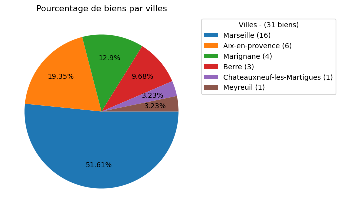

```python
villes, nb_bien = np.unique(bien["VILLE"], return_counts=True)
for i in range(len(villes)):
    villes[i] = villes[i] + " (" + str(nb_bien[i]) + ")"
df = pd.DataFrame({
    'Villes': villes,
    'Nb_bien': nb_bien
})
df = df.sort_values(by=["Nb_bien"], ascending=False)
fig, ax = plt.subplots(figsize=(8, 5), subplot_kw=dict(aspect="equal"))
wedges, texts, autotexts = ax.pie(df.Nb_bien, autopct=lambda z: str(
    round(z, 2)) + '%', pctdistance=0.7,
    textprops=dict(color="black"), counterclock=False)
ax.legend(wedges, df.Villes,
          title="Villes - (" + str(len(bien)) + " biens)",
          loc="best",
          bbox_to_anchor=(1, 0, 0.5, 1))
plt.setp(autotexts, size=10)
ax.set_title("Pourcentage de biens par villes")
```

Ce diagramme circulaire montre la proportion de biens par ville. Par définition, ce diagramme est le plus adéquat pour représenter les proportions au sein d'une même population.

Cette visualisation permet de montrer aux acheteurs sur quelles villes on aura le plus de propositions, pour la raison que certains acheteurs ont parfois certaines villes qu'ils abhorent ou d'autres dans lesquelles leurs préférences se situent.

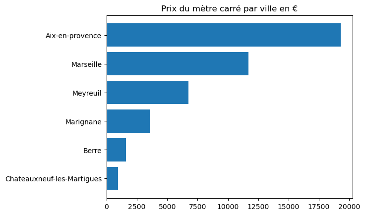

```python
villes = np.unique(bien["VILLE"])
idebien_par_ville = []
for ville in villes:
    idebien_par_ville.append([])
    for idebien in bien["IDEBIEN"].loc[(bien["VILLE"] == ville)]:
        idebien_par_ville[-1].append(idebien)
somme_espace_par_ville = []
somme_prix_par_ville = []
for ville in idebien_par_ville:
    somme_espace_par_ville.append(0)
    somme_prix_par_ville.append(0)
    for idebien in ville:
        somme_espace_par_ville[-1] += int(espace.loc[espace["IDE"]
                                                     == idebien]["SUPERFICIE"])
        somme_prix_par_ville[-1] += int(bien.loc[bien["IDEBIEN"]
                                                 == idebien]["PRIX"])
prix_mettre_carre = []
for i in range(len(villes)):
    prix_mettre_carre.append(somme_prix_par_ville[i]/somme_espace_par_ville[i])
df = pd.DataFrame({
    'Villes': villes,
    'Prix': prix_mettre_carre
})
df = df.sort_values(by=["Prix"])
plt.barh(y=df.Villes, width=df.Prix, align='center')
plt.title('Prix du mètre carré par ville en €')
plt.show()
```

Ce diagramme en bâton montre le prix moyen du mètre carré par ville. Son organisation par l'ordre décroissant du prix et à l'horizontal permet une meilleure visibilité et hiérarchise les villes les plus chères.

Grâce à cette information, l'achetteur peut mieux estimer la ville où il voudra s'installer, ou simplement acheter un bien. Là où le mettre carré est plus élevé, les biens sont plus chers et le voisinage sera plus aisé, donc potentiellement d'une classe sociale plus haute, et vice versa.

(Soulignons qu'il est flagrant ici qu'il figure des incohérences dans notre base de données par rapport à la réalité. Alors il ne faut que considérer la pertinence de nos diagrames et de notre manière de les montrer, argumenter ; et non de nos données en eles-même.)

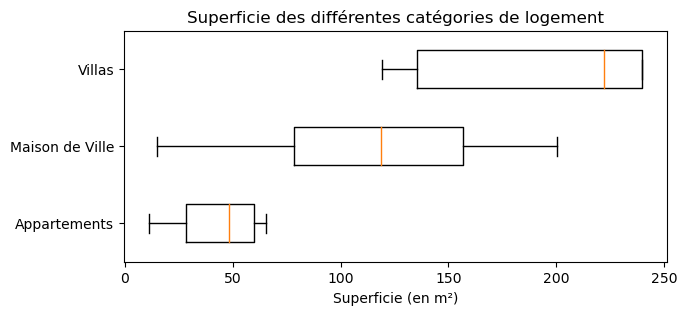

```python
espaceBien = espace[espace["IDE"].isin(bien["IDEBIEN"])]
superficieEspacesAppart = espaceBien.loc[espaceBien["DESIGNATION"] == 'Appartement']["SUPERFICIE"]
superficieEspacesMaisonVille = espaceBien.loc[espaceBien["DESIGNATION"] == 'Maison de ville']["SUPERFICIE"]
superficieEspacesVilla = espaceBien.loc[espaceBien["DESIGNATION"] == 'Villa']["SUPERFICIE"]

plt.figure(figsize=(7,3))
plt.boxplot([superficieEspacesAppart,superficieEspacesMaisonVille,superficieEspacesVilla],labels = ["Appartements","Maison de Ville","Villas"], whis=[0,100], vert=False,widths=0.5)
plt.xlabel("Superficie (en m²)")
plt.title("Superficie des différentes catégories de logement")
plt.show()
```

Ces trois diagrammes en boite montrent les indicateurs statistiques des superficies pour chaque type de bien. C'est une synthèse efficace des données sur la superficies des biens de l'agence et permet parallèlement de comparer les indicateurs entre eux.

Cette information complémente le diagramme précédent en montrant des indicateurs pertinents sur la superficie des biens de l'agence. L'acheteur estime tout de suite à la vue de ces statistiques si l'agence est susceptible de proposer des biens dont la superficie leur convient.

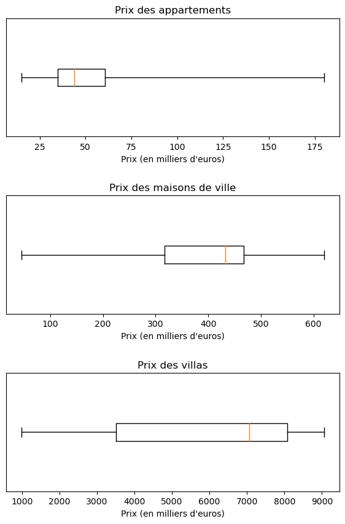

```python
prix_appart = bien.loc[(bien["CATEGORIE"] == "Appartement")]["PRIX"]
prix_maisonville = bien.loc[(bien["CATEGORIE"] == "Maison de ville")]["PRIX"]
prix_villa = bien.loc[(bien["CATEGORIE"] == "Villa")]["PRIX"]

fig, (ax1, ax2, ax3) = plt.subplots(3,1, figsize=(7,10))

ax1.set_title("Prix des appartements")
ax1.boxplot(np.multiply(prix_appart,0.001), whis=[0,100], vert=False)
ax1.set_xlabel("Prix (en milliers d'euros)")
ax1.set_yticklabels("")
ax1.tick_params(axis='y', left=False)

ax2.set_title("Prix des maisons de ville")
ax2.boxplot(np.multiply(prix_maisonville,0.001), whis=[0,100], vert=False)
ax2.set_xlabel("Prix (en milliers d'euros)")
ax2.set_yticklabels("")
ax2.tick_params(axis='y', left=False)


ax3.set_title("Prix des villas")
ax3.boxplot(np.multiply(prix_villa,0.001), whis=[0,100], vert=False)
ax3.set_xlabel("Prix (en milliers d'euros)")
ax3.set_yticklabels("")
ax3.tick_params(axis='y', left=False)

plt.subplots_adjust(hspace=0.5)
plt.show()
```

Ces trois diagrammes en boîte montrent des indicateurs statistique pertinents sur le prix des biens de l'agence selon leur catégorie. Dû à leur trop grande différene de valeurs ils ne peuvent pas figurer sur le même diagramme, mais les informatiosn y restent claires et intuitives.

Il permet à l'acheteur de savoir si les biens de l'agence correspondent à ce qu'il recherche, selon la catégorie de bien qu'il veut et le prix qu'il est prêt à y mettre. Les maximum, minimum, médiane et quartides permettent de se faire une idée de la quantité de biens à disposition dans chaque tranche de prix.

## Cahier de bord

Cette partie se veut relater brièvement comment s'est déroulé notre travail d'une semaine fournit sur cette SAE. Peut être ces informations ne seront pas d'intérêt ; mais au cas où elles le sont, les voicies.

Les membres du groupe qui a composé ce devoir proviennent de deux groupes différents ( reformation des groupes qui a eu lieu suite à un quiproquo ). Ainsi, le projet déjà entamé avec notre groupe d'origine a servit de base à notre projet, puisque nous avions déjà fournit un travail important dans ces devoirs, et que nous n'avions absolument pas le temps de recommencer à zéro. En formant ce nouveau groupe de trois, l'on a cherché des membres qui seraient en capacité de conduire et finaliser ce projet en un temps plus court.

Ainsi, bien qu'il est nécessaire que chacun connaisse l'entièreté du travail effectué (ce qui est le cas), nous avons dû séparer distinctement les taches par soucis d'efficacité et de rapidité. Une fois la base de donnée terminée, l'un s'est consacré à la formation et rédaction du rapport quand les deux autres produisaient autant que possible des visualisations statistiques pour enrichir le rapport.

De cette manière, à terme de seulement quatre heures, le groupe a pu :

```
- Se former et s'organiser.
- Récupérer les données utiles de son précédent groupe de travail.
- Ajuster et finaliser la base de donnée.
- Se mettre en accord sur les statistiques à produire, ainsi que sur la forme et le fond du rapport.
- Produire plusieurs visualisations toutes implémentées dans le rapport.
```

Finalement, il suffira aux trois jours restants pour finaliser le rapport, et les trois jours d'amont à la soutenance permettront de récupérer toutes les informations nécessaires dans le rapport, créer le support de présentation oral, s'organiser et s'entrainer.

L'on aura bien pris l'initiative de tester d'autres diagrammes, en exemble ; le diagrramme en violon, mais cela ne nous aura pas semblé pertinent alors ces tentatives ne figurent pas au rapport.

Aucun problème important n'est survenu pendant la création du devoir, cela grâce aux consignes claires, à l'initiative individuelle de chacun, et à l'organisation faite en amont. Pour cela, chacun avait les compétences nécessaires pour produire de travail.

## Conclusion

Précisons une dernière fois que l'organisation des visualisations relève parfois du subjectif, puisque certaines informations peuvent concerner plusieurs acteurs essentiellements et fonctionnellements différents. Nous avons néanmoins cherché de la cohérence, et systématiquement expliqué nos arguments.

Bien que la qualité nous a été un soucis important, notre principale affaire était de produire le plus de visualisations statistiques ; seules les plus pertinentes sont présentes sur le rapport. Le soucis de quantité nous est aussi important pour la présentation orale à préparer postérieurement à ce rapport et dont toute la matière doit en être tiré ; plus nous avons d'information, plus notre marge de manoeuvre est importante.

Nous espérons que ce rapport aura été assez bien rédigé et organisé pour permettre de comprendre au mieux les travaux effectués, et que l'effort que nous avons mis pour donner des informations cohérentes dans une forme cohérente saura porter ses fruits.